# Lab 01 - Hello R

Eric!

12.30.23

## Load packages and data

```r
library(tidyverse)
library(datasauRus)
# install fun themes
if (!requireNamespace("ThemePark", quietly = TRUE)) {
    remotes::install_github("MatthewBJane/ThemePark")
}
library(ThemePark)


# Set options to print all rows of data frames/tibbles
options(tibble.print_max = Inf)  # For tibbles
options(max.print = .Machine$integer.max)  # For data frames
```

## Exercises

### Exercise 1

Based on the help file, how many rows and how many columns does the datasaurus_dozen file have? What are the variables included in the data frame? Add your responses to your lab report.

According to the help, there are 1846 rows and 3 variables. I was confused by this at first, because if there are lots of data sets, how can there just be 3 variables? But I’m now thinking of it that there are 3 *columns* where 2 of the columns are essentially *x* and *y*, and x and y take on different meanings in the different data sets (e.g., for dino, dots, etc). Is that accurate?

The three variables / columns are:  
(1) which data set the data are from (2) x-values (3) y-values

The different data sets are:

1 away  
2 bullseye  
3 circle  
4 dino  
5 dots  
6 h_lines  
7 high_lines 8 slant_down 9 slant_up  
10 star  
11 v_lines  
12 wide_lines 13 x_shape

```r
nrow(datasaurus_dozen)
```

```
## [1] 1846
```

```r
ncol(datasaurus_dozen)
```

```
## [1] 3
```

```r
datasaurus_dozen %>% select(dataset) %>% unique() %>% print(n = Inf)
```

```
## # A tibble: 13 × 1
##    dataset
##    <chr>
##  1 dino
##  2 away
##  3 h_lines
##  4 v_lines
##  5 x_shape
##  6 star
##  7 high_lines
##  8 dots
##  9 circle
## 10 bullseye
## 11 slant_up
## 12 slant_down
## 13 wide_lines
```

### Exercise 2

First let’s plot the data in the dino dataset:

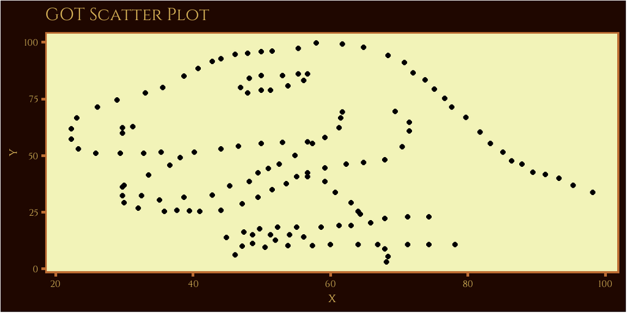

```r
dino_data <- datasaurus_dozen %>%
  filter(dataset == "dino")

ggplot(data = dino_data, mapping = aes(x = x, y = y)) +
  geom_point()+
    labs(title = "GOT Scatter Plot")+
    theme_gameofthrones()
```

The graph looks like a dinosaur. Note if you change the commands to:

ggplot(data = dino_data, mapping = aes(x = y, y = x)) + geom_point()

the dinosaur is lying down!

And next calculate the correlation between `x` and `y` in this dataset:

```r
dino_data %>%
  summarize(r = cor(x, y))
```

```
## # A tibble: 1 × 1
##         r
##     <dbl>
## 1 -0.0645
```

The correlation is -0.0645

### Exercise 3

Plot y vs. x for the star dataset. You can (and should) reuse code we introduced above, just replace the dataset name with the desired dataset. Then, calculate the correlation coefficient between x and y for this dataset. How does this value compare to the r of dino?

Add code and narrative as needed. Note that the R chunks are labeled with `plot-star` and `cor-star` to provide spaces to place the code for plotting and calculating the correlation coefficient. To finish, clean up the narrative by removing these instructions.

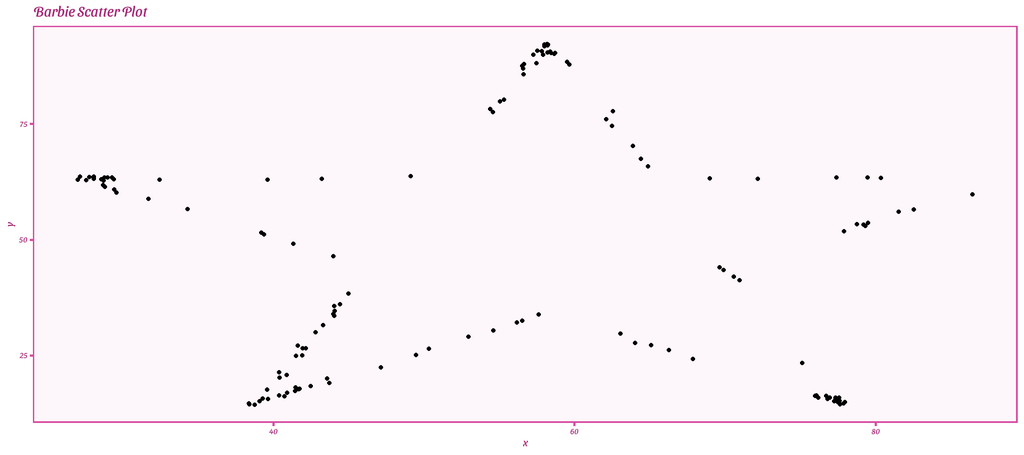

```r
star_data <- datasaurus_dozen %>%
  filter(dataset == "star")

ggplot(data = star_data, mapping = aes(x = x, y = y)) +
  geom_point() +
    labs(title = "Barbie Scatter Plot")+
    theme_barbie()
```

The graph looks like a star.

```r
star_data %>%
  summarize(r = cor(x, y))
```

```
## # A tibble: 1 × 1
##         r
##     <dbl>
## 1 -0.0630
```

r = -.0630

Basically the same correlation from before. So just based on the linear correlations, the associations between x and y are identical. Hence a good example of why linear relationships don’t tell the whole story! :)

### Exercise 4

Add code and narrative as needed. Note that two R chunks are given but they are not labeled. Use the convention from above to name them appropriately.

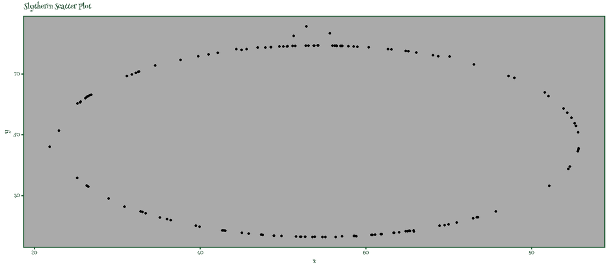

```r
circle_data <- datasaurus_dozen %>%
  filter(dataset == "circle")

ggplot(data = circle_data, mapping = aes(x = x, y = y)) +
  geom_point()+
    labs(title = "Slytherin Scatter Plot")+
    theme_slytherin()
```

```r
circle_data %>%
  summarize(r = cor(x, y))
```

```
## # A tibble: 1 × 1
##         r
##     <dbl>
## 1 -0.0683
```

The correlation is -.0683 … again, the same as in dino.

### Exercise 5

Add code and narrative as needed.

To add R chunks either type out the backticks, curly braces, and the letter `r` or use the Insert chunk button above, green C+.

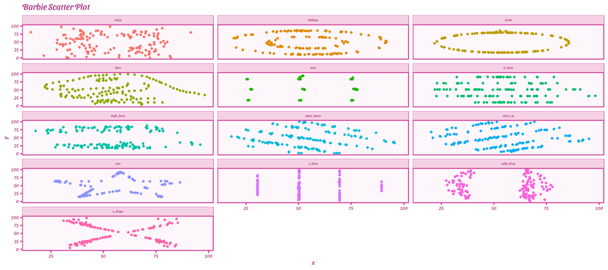

```r
ggplot(datasaurus_dozen, aes(x = x, y = y, color = dataset))+
  geom_point()+
  facet_wrap(~ dataset, ncol = 3) +
  labs(title = "Barbie Scatter Plot")+
  theme_barbie(legend.position = "none")
```

```r
datasaurus_dozen %>%
  group_by(dataset) %>%
  summarize(r = cor(x, y)) %>%
  print(n=Inf)
```

```
## # A tibble: 13 × 2
##    dataset          r
##    <chr>        <dbl>
##  1 away       -0.0641
##  2 bullseye   -0.0686
##  3 circle     -0.0683
##  4 dino       -0.0645
##  5 dots       -0.0603
##  6 h_lines    -0.0617
##  7 high_lines -0.0685
##  8 slant_down -0.0690
##  9 slant_up   -0.0686
## 10 star       -0.0630
## 11 v_lines    -0.0694
## 12 wide_lines -0.0666
## 13 x_shape    -0.0656
```

Note when I run the above command it shows the correlations, but when I knitted it the correlations did not appear. Which makes me think the second variable (i.e., the correlation) isn’t showing up. Shouldn’t run and knit produce the same results?

> That’s a good question. So they should if you give it explicit print options, but otherwise, the defaults provided in R studio and the defaults provided in knitr might not be the same. You’ll also see this with digits etc. So you can always specify how you would like the information to appear, like I’ve done in this version.